# Decisión basada en hechos

En la gestión de la calidad, la gestión basada en hechos es crucial, y para ello, se requiere tomar nuestras representativas de la población, y procesar correctamente los datos obtenidos de forma estadistica.

```python
import os

try:
  os.chdir('../Python/QCKentei4')
except:
  pass

path = os.getcwd()
path
```

```
'/Users/takanohiroshi/Library/CloudStorage/OneDrive-YokohamaInternationalExchangeAssociation/Python/QCKentei4'
```

```python
import numpy as np
import matplotlib.pyplot as plt
import pandas as pd
import random
from scipy.stats import norm

from PIL import Image

import gspread
from google.oauth2.service_account import Credentials
```

## 07-01 Fundamentos de los datos / Bases de los datos

### 1. Población y muestra

- Gesticón basada en hechos / Administración basada en hechos / Control basado en hechos
- Variabilidad / Dispersión / Variación
- Muestra
- Población

### 2. Muestreo

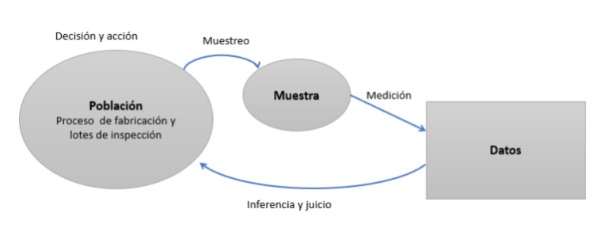

```python
img = Image.open('./Data4/Muestra.png')
display(img)
```

## 07-02 Lotes

### 1. Lotes

Un lote es un conjunto de artículos que se producen o se considera que han sido producidos bajo condiciones iguales.

## 07-03 Tipos de datos (datos cuantitativos, datos de atributos)

## 07-04 Recopilación y resumen de datos

### 1. Método de recolección de datos

- Muestreo aleatorio

### 2. Método de organización de datos

En la Tabla 7.1 se presenta un resumen de los datos del seguimiento del peso del Sr. H desde lunes hasta el viernes.

```python
SERVICE_ACCOUNT_FILE = "my-project-vscode-452201-249bdb033f8c.json"  # JSONファイルのパス
SCOPES = ["https://www.googleapis.com/auth/spreadsheets"]

credentials = Credentials.from_service_account_file(SERVICE_ACCOUNT_FILE, scopes=SCOPES)
client = gspread.authorize(credentials)

# スプレッドシートを開く（URLまたはスプレッドシートIDを使用）
SPREADSHEET_ID = "1nsctbBbtIW-6C4BFP7jqKB-4-8AHHPWZ0sfwpZ1GPDY"
sheet = client.open_by_key(SPREADSHEET_ID).worksheet("Sheet3") # 最初のシートを取得

list_of_lists = sheet.get_all_values()

df = pd.DataFrame.from_records(list_of_lists, index=0)

df.columns = df.iloc[0]
df = df.drop(df.index[0])
df = df.set_index("Dia")
df = df.astype(float)

print('Tabla 7.1')
df
```

```
Tabla 7.1
```

| Dia | Lun | Mar | Mie | Jue | Vie |
| --- | --- | --- | --- | --- | --- |
| Peso | 65.0 | 67.8 | 67.3 | 66.4 | 68.4 |

## 07-05 El concepto de promedio y dispersión

## 07-06 Media y rango

### 1. Medidas de tendencia central: media y mediana

#### (1) media

$ \bar{x} = \frac{1}{n} \sum_{i=1}^n x_i $

#### (2) mediana

La mediana es el valor central de un conjunto de datos ordenados de menor a mayor. Si el número de datos es par, se calcula la mdedia de los dos valores centrales.

### 2. Medidas de dispersión: rango

```python
import pandas as pd
import matplotlib.pyplot as plt

def summarize_series(series: pd.Series):

    mean_val = np.round(series.mean(),2)
    median_val = np.round(series.median(),2)
    min_val = series.min()
    max_val = series.max()
    range_val = np.round((max_val - min_val),1)

    summary = {
        'media': mean_val,
        'mediana': median_val,
        'rango': range_val
    }

    # 可視化
    plt.figure(figsize=(10, 2))
    y = [1] * len(series)  #


    # 元データ点
    plt.scatter(series, y, color='skyblue', label='Data')

    # 平均値の線
    plt.axvline(mean_val, color='red', linestyle='--', label=f'Media: {mean_val:.2f}')

    # 中央値の点（強調）
    plt.scatter([median_val], [1], color='orange', s=100, label=f'Mediana: {median_val:.1f}', zorder=5)

    # 最小値と最大値
    plt.axvline(min_val, color='gray', linestyle=':', label=f'Min: {min_val:.1f}')
    plt.axvline(max_val, color='gray', linestyle=':', label=f'Max: {max_val:.1f}')

    plt.title('')
    plt.yticks([])
    plt.xlabel('')
    plt.legend(loc='upper center', bbox_to_anchor=(0.5, 1.3), ncol=4)
    plt.grid(axis='x', linestyle='--', alpha=0.5)
    plt.tight_layout()
    plt.show()

    return summary
```

```
Dia    Lun   Mar   Mie   Jue   Vie
Dia
Peso  65.0  67.8  67.3  66.4  68.4
```

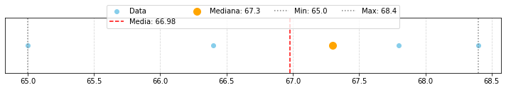

```
{'media': 66.98, 'mediana': 67.3, 'rango': 3.4}
```

```python
print(df)

series = df.iloc[0]
summary = summarize_series(series)

# すべてをfloatに変換
summary = {k: float(v) for k, v in summary.items()}
print(summary)
```

## 7.5

在宅勤務が増え、一年前にくらべ従業員の体重が増えたのではないかということを検証するために、ランダムに９名を選び、体重の変化のデータをとり表７．４に集計した。

下記を計算せよ。

1. 平均値
2. 中央値
3. 最小値、最大値、範囲

Debido al aumento del teletrabajo, para verificar si el peso de los empleados ha aumentado en comparación con hace un año, se seleccionaron aleatoriamente a 9 personas y se recopilaron los datos del cambio de peso en la Tabla 7.4.

Calcular lo siguiente:

1. Media
2. Mediana
3. Valor mínimo, valor máximo, rango

```python
sheet = client.open_by_key(SPREADSHEET_ID).worksheet("Sheet4") # 最初のシートを取得

list_of_lists = sheet.get_all_values()

df = pd.DataFrame.from_records(list_of_lists, index=0)

df.columns = df.iloc[0]
df = df.drop(df.index[0])
df = df.set_index("Nom")
df = df.astype(float)

print('Tabla 7.4')
df
```

```
Tabla 7.4
```

| Nom | A | B | C | D | E | F | G | H | I |
| --- | --- | --- | --- | --- | --- | --- | --- | --- | --- |
| Peso | 1.3 | 0.2 | -1.4 | 3.5 | 0.0 | 14.1 | 5.7 | 4.1 | -2.2 |

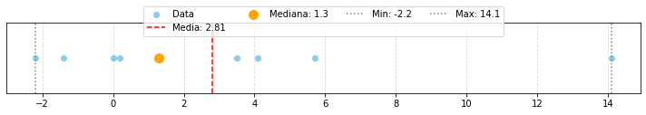

```
{'media': 2.81, 'mediana': 1.3, 'rango': 16.3}
```

```python
series = df.iloc[0]
summary = summarize_series(series)
summary = {k: float(v) for k, v in summary.items()}

print(summary)
```

体重の変化に変化があったといえるかどうかの検証

Verificación de si hubo cambio en la variación del peso.

```python
from scipy import stats

peso = series.to_numpy()

# 平均と標準誤差
mean_change = np.mean(peso)
sem = stats.sem(peso)

# 95%信頼区間の計算
confidence = 0.95
n = len(peso)
df = n - 1
t_critical = stats.t.ppf((1 + confidence) / 2, df)
ci_lower = mean_change - t_critical * sem
ci_upper = mean_change + t_critical * sem

# t検定（平均がゼロか）
t_stat, p_value = stats.ttest_1samp(peso, 0)

# 結果の出力
print(f"平均体重変化: {mean_change:.2f}")
print(f"95%信頼区間: ({ci_lower:.2f}, {ci_upper:.2f})")
print(f"t値: {t_stat:.2f}, p値: {p_value:.4f}")

# 検定結果の解釈
if p_value < 0.05:
    print("Hubo un cambio estadísticamente significativo en el peso.（p < 0.05）。")
else:
    print("No hubo cambio estadísticamente significativo en el peso.（p >= 0.05）。")
```

```
平均体重変化: 2.81
95%信頼区間: (-1.01, 6.63)
t値: 1.70, p値: 0.1283
No hubo cambio estadísticamente significativo en el peso.（p >= 0.05）。
```

Zスコア、箱ひげ図による外れ値検出

Detección de valores atípicos mediante la Punteje Z y el Diagrama de caja.

```
Zスコアによる外れ値検出（|z| > 2）:
値: 14.1, Zスコア: 2.41

箱ひげ図（IQR）による外れ値検出:
IQR範囲: [-6.15, 10.25]
外れ値: [14.1]
```

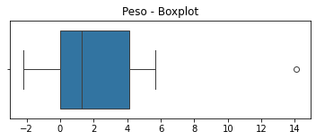

```python
import seaborn as sns

# Zスコアによる外れ値検出
mean = np.mean(peso)
std = np.std(peso)
z_scores = (peso - mean) / std
outliers_z = peso[np.abs(z_scores) > 2]  # 閾値は通常2または3

print("Zスコアによる外れ値検出（|z| > 2）:")
for val, z in zip(peso, z_scores):
    if np.abs(z) > 2:
        print(f"値: {val:.1f}, Zスコア: {z:.2f}")

# 箱ひげ図による外れ値検出（IQR）
q1 = np.percentile(peso, 25)
q3 = np.percentile(peso, 75)
iqr = q3 - q1
lower_bound = q1 - 1.5 * iqr
upper_bound = q3 + 1.5 * iqr

outliers_iqr = peso[(peso < lower_bound) | (peso > upper_bound)]

print("\n箱ひげ図（IQR）による外れ値検出:")
print(f"IQR範囲: [{lower_bound:.2f}, {upper_bound:.2f}]")
print("外れ値:", outliers_iqr)

# 可視化：箱ひげ図
plt.figure(figsize=(6, 2))
sns.boxplot(x=peso)
plt.title("Peso - Boxplot")
plt.show()
```

## 7.6

小学校の生徒１０人をランダムに抜き出し、体力測定結果を表７．３に示す。

1. 各生徒の合計、平均値、中央値を求める
2. 全体の合計、平均を求める
3. クラス別の合計、平均値、最小値、最大値、範囲をもとめる。

Se seleccionaron aleatoriamente a 10 alumnos de primaria y sus resultados de las prebas físicas se muestran en la Tabla 7.3.

Calcular:

1. El total, la media y la mediana de cada alumno.
2. El total y la media general.
3. El total, la mdedia, el mínimo, el máximo, el rango por clase.

```python
sheet = client.open_by_key(SPREADSHEET_ID).worksheet("Sheet5") # 最初のシートを取得

list_of_lists = sheet.get_all_values()

df = pd.DataFrame.from_records(list_of_lists, index=0)

df.columns = df.iloc[0]
df = df.drop(df.index[0])

df5 = df.copy()

df = df.set_index(['Clase',"Nom"])

df= df.astype(int)
df2 = df.copy()

print('Tabla 7.3')
df
```

```
Tabla 7.3
```

| Clase | Nom | Vel. Corta | Res. Largo | Salto V. | Lanz. Balón | Salt. Lat. |
| --- | --- | --- | --- | --- | --- | --- |
| 1 | A | 4 | 3 | 4 | 4 | 3 |
|  | B | 2 | 4 | 3 | 3 | 4 |
|  | C | 3 | 3 | 2 | 3 | 2 |
| 2 | D | 4 | 2 | 3 | 3 | 1 |
|  | E | 2 | 2 | 3 | 2 | 1 |
|  | F | 5 | 5 | 5 | 3 | 4 |
| 3 | G | 3 | 2 | 4 | 1 | 4 |
|  | H | 3 | 4 | 3 | 3 | 3 |
|  | I | 4 | 3 | 4 | 2 | 4 |
|  | J | 2 | 3 | 2 | 2 | 3 |

```python
df.describe()
```

| Nom | Vel. Corta | Res. Largo | Salto V. | Lanz. Balón | Salt. Lat. |
| --- | --- | --- | --- | --- | --- |
| count | 10.000000 | 10.000000 | 10.000000 | 10.000000 | 10.000000 |
| mean | 3.200000 | 3.100000 | 3.300000 | 2.600000 | 2.900000 |
| std | 1.032796 | 0.994429 | 0.948683 | 0.843274 | 1.197219 |
| min | 2.000000 | 2.000000 | 2.000000 | 1.000000 | 1.000000 |
| 25% | 2.250000 | 2.250000 | 3.000000 | 2.000000 | 2.250000 |
| 50% | 3.000000 | 3.000000 | 3.000000 | 3.000000 | 3.000000 |
| 75% | 4.000000 | 3.750000 | 4.000000 | 3.000000 | 4.000000 |
| max | 5.000000 | 5.000000 | 5.000000 | 4.000000 | 4.000000 |

```python
df["Sum"] = df2.sum(axis=1)
df['Promedio'] = df2.mean(axis=1)
df['Median'] = df2.median(axis=1)
df3 = df.copy()

ave = df['Promedio'].mean()
ave2 = df['Median'].mean()
df.loc['Total'] = df.sum()
df.iloc[10,6] = ave
df.iloc[10,7] = ave2

print('Tabla 7.5')
df
```

```
Tabla 7.5
```

| Nom | Vel. Corta | Res. Largo | Salto V. | Lanz. Balón | Salt. Lat. | Sum | Promedio | Median |
| --- | --- | --- | --- | --- | --- | --- | --- | --- |
| (1, A) | 4.0 | 3.0 | 4.0 | 4.0 | 3.0 | 18.0 | 3.60 | 4.0 |
| (1, B) | 2.0 | 4.0 | 3.0 | 3.0 | 4.0 | 16.0 | 3.20 | 3.0 |
| (1, C) | 3.0 | 3.0 | 2.0 | 3.0 | 2.0 | 13.0 | 2.60 | 3.0 |
| (2, D) | 4.0 | 2.0 | 3.0 | 3.0 | 1.0 | 13.0 | 2.60 | 3.0 |
| (2, E) | 2.0 | 2.0 | 3.0 | 2.0 | 1.0 | 10.0 | 2.00 | 2.0 |
| (2, F) | 5.0 | 5.0 | 5.0 | 3.0 | 4.0 | 22.0 | 4.40 | 5.0 |
| (3, G) | 3.0 | 2.0 | 4.0 | 1.0 | 4.0 | 14.0 | 2.80 | 3.0 |
| (3, H) | 3.0 | 4.0 | 3.0 | 3.0 | 3.0 | 16.0 | 3.20 | 3.0 |
| (3, I) | 4.0 | 3.0 | 4.0 | 2.0 | 4.0 | 17.0 | 3.40 | 4.0 |
| (3, J) | 2.0 | 3.0 | 2.0 | 2.0 | 3.0 | 12.0 | 2.40 | 2.0 |
| Total | 32.0 | 31.0 | 33.0 | 26.0 | 29.0 | 151.0 | 3.02 | 3.2 |

```python
result1 = df3.groupby('Clase').agg({'Sum':'sum', 'Promedio':'mean'})

target_columns = df3.columns[:5]  #

# Claseごとに groupby し、各グループ内の全体での max/min を求めて範囲を出す
def get_range_stats(group):
    max_val = group[target_columns].max().max()
    min_val = group[target_columns].min().min()
    value_range = max_val - min_val
    return pd.Series({'Max': max_val, 'Min': min_val, 'Rango': value_range})

# 適用
resul2 = df3.groupby('Clase').apply(get_range_stats)

result = pd.concat([result1, resul2], axis=1)

print(result)
```

```
       Sum  Promedio  Max  Min  Rango
Clase
1       47  3.133333    4    2      2
2       45  3.000000    5    1      4
3       59  2.950000    4    1      3
```

## Creación de gráficos de radar por alumn y por clase

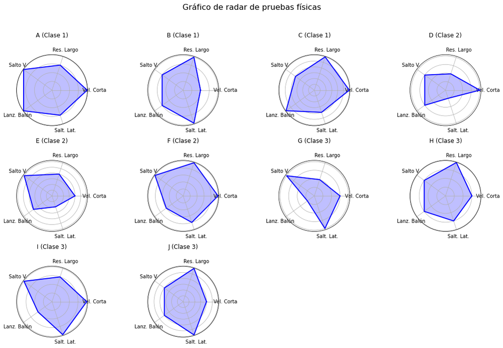

```python
df = df5.copy()
df.iloc[:,2:] = df.iloc[:,2:].astype(int)

# 指標
labels = df.columns[2:]
num_vars = len(labels)

# 角度設定
angles = np.linspace(0, 2 * np.pi, num_vars, endpoint=False).tolist()
angles += angles[:1]  # 最初の値を最後に追加して円を閉じる

# 描画
fig, axes = plt.subplots(3, 4, subplot_kw=dict(polar=True), figsize=(15, 10))
fig.suptitle("Gráfico de radar de pruebas físicas", fontsize=16)

for idx, ax in enumerate(axes.flatten()):
    if idx >= len(df):
        ax.axis('off')  # データがない場合は非表示
        continue

    row = df.iloc[idx]
    values = row[labels].tolist()
    values += values[:1]  # 最初の値を最後に追加して閉じる

    ax.plot(angles, values, color='b', linewidth=2)
    ax.fill(angles, values, color='b', alpha=0.25)
    ax.set_title(f"{row['Nom']} (Clase {row['Clase']})\n", size=12)
    ax.set_xticks(angles[:-1])
    ax.set_xticklabels(labels, fontsize=10)
    ax.set_yticklabels([])

plt.tight_layout(rect=[0, 0, 1, 0.95])
plt.show()
```

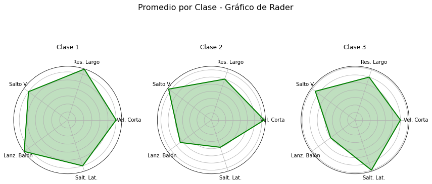

```python
# 指標
num_vars = len(labels)
angles = np.linspace(0, 2 * np.pi, num_vars, endpoint=False).tolist()
angles += angles[:1]  # 円を閉じる

# Claseごとに平均値を計算
clase_means = df.groupby("Clase")[labels].mean()

# 描画
fig, axes = plt.subplots(1, 3, subplot_kw=dict(polar=True), figsize=(12, 6))
fig.suptitle("Promedio por Clase - Gráfico de Rader", fontsize=16)

for i, (clase, row) in enumerate(clase_means.iterrows()):
    values = row.tolist()
    values += values[:1]  # 円を閉じる

    ax = axes[i]
    ax.plot(angles, values, linewidth=2, label=f'Clase {clase}', color='green')
    ax.fill(angles, values, alpha=0.25, color='green')
    ax.set_title(f'Clase {clase}\n', size=12)
    ax.set_xticks(angles[:-1])
    ax.set_xticklabels(labels, fontsize=10)
    ax.set_yticklabels([])

plt.tight_layout(rect=[0, 0, 1, 0.95])
plt.show()
```

```python
notebook_name = 'QCKentei4-7.ipynb'
notebook_name_html = notebook_name.replace(".ipynb",".html")

!jupyter nbconvert --to html {notebook_name}
```

```
[NbConvertApp] Converting notebook QCKentei4-7.ipynb to html
[NbConvertApp] Writing 1189627 bytes to QCKentei4-7.html
```

```python
from IPython.display import display
from PIL import Image
import gdown
import re

def get_file_id(url,out):
    # 正規表現でファイルIDを抽出
    match = re.search(r'/d/([a-zA-Z0-9_-]+)', url)

    if match:
        file_id = match.group(1)
        print("ファイルID:", file_id)
    else:
        print("ファイルIDが見つかりませんでした。")

    url = f"https://drive.google.com/uc?id={file_id}"

    output = out

    gdown.download(url, output, quiet=False)

    img = Image.open(out)
    display(img)
```

```
ファイルID: 1MvFg0SHw7HQEGz4FrITeri_InTzmgqv7
```

```
Downloading...
From: https://drive.google.com/uc?id=1MvFg0SHw7HQEGz4FrITeri_InTzmgqv7
To: /Users/takanohiroshi/Library/CloudStorage/OneDrive-YokohamaInternationalExchangeAssociation/Python/QCKentei4/Data4/Muestra.png
```

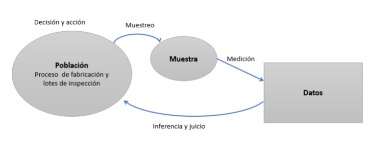

```python
url= 'https://drive.google.com/file/d/1MvFg0SHw7HQEGz4FrITeri_InTzmgqv7/view?usp=drive_link'
out = './Data4/Muestra.png'
get_file_id(url,out)
```